# Project 1: Deaths from Measles and Whooping Cough in London

#### 5. Dimensionality Reduction (30 pts)

- Either k-means/PAM clustering or PCA (inclusive “or”) should be performed on at least three of your variables (3 is just the minimum: using more/all of them will make this much more interesting!)
  - All relevant steps discussed in class (e.g., picking number of PCs/clusters)
  - A visualization of the clusters or the first few principal components (using ggplot2)
  - Supporting paragraph or two describing results found, interpreting the clusters/PCs in terms of the original variables and observations, discussing goodness of fit or variance explained, etc.

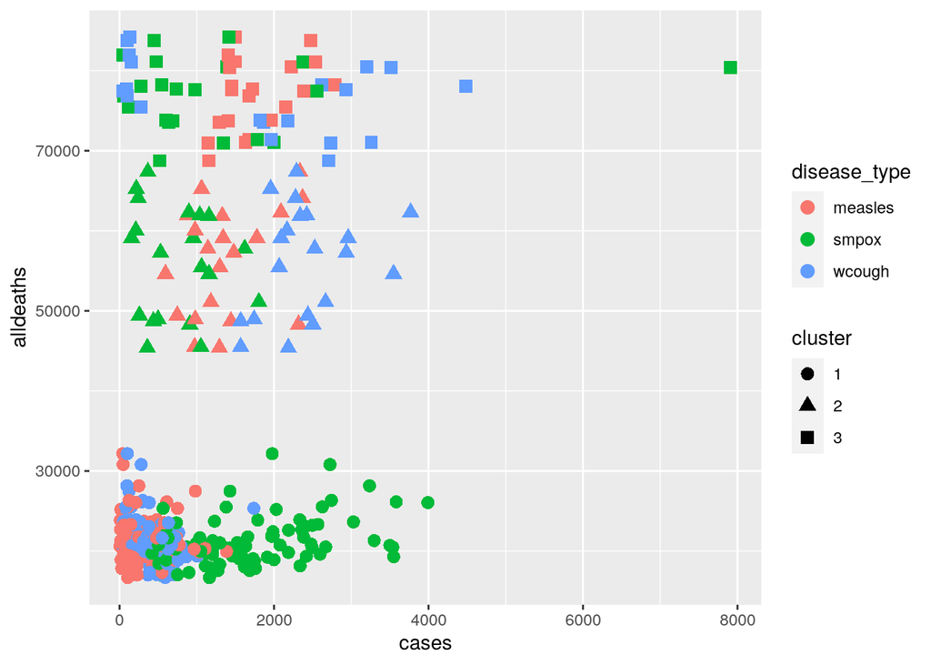

```r
library(cluster)
three_diseases <- trial %>% select(disease_type, cases, alldeaths)
pam1 <- trial %>% pam(k = 3)
pamcluster <- three_diseases %>% mutate(cluster = as.factor(pam1$cluster))
pamcluster %>% ggplot(aes(cases, alldeaths, color = disease_type,
    shape = cluster)) + geom_point(size = 3)
```

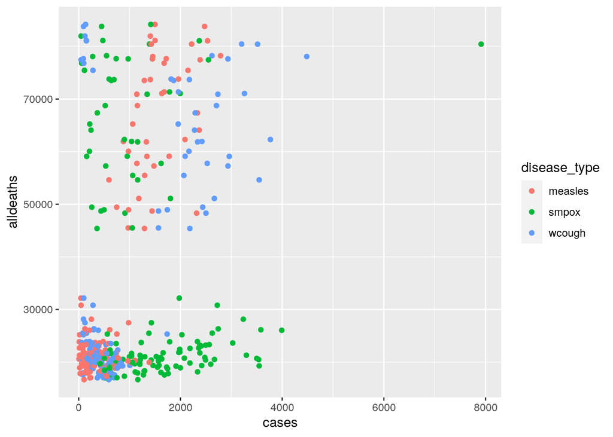

```r
trial %>% ggplot(aes(cases, alldeaths, color = disease_type)) +
    geom_point()
```